# finalproject

HyeongHwan Kim

2023-11-06

```r
library(stringr)
```

```r
library(purrr)
library(ggplot2)
library(forcats)
library(dplyr)
library(tidyverse)
library(readr)
library(ISLR2)
library(leaps)
library(tidymodels)
```

# TOPIC 1: Student Performance

## Q1

```r
mat_df <- read.table("student-mat.csv",sep=";",header=TRUE)
por_df <- read.table("student-por.csv",sep=";",header=TRUE)
```

```r
head(mat_df)
```

```
##   school sex age address famsize Pstatus Medu Fedu     Mjob     Fjob     reason
## 1     GP   F  18       U     GT3       A    4    4  at_home  teacher     course
## 2     GP   F  17       U     GT3       T    1    1  at_home    other     course
## 3     GP   F  15       U     LE3       T    1    1  at_home    other      other
## 4     GP   F  15       U     GT3       T    4    2   health services       home
## 5     GP   F  16       U     GT3       T    3    3    other    other       home
## 6     GP   M  16       U     LE3       T    4    3 services    other reputation
##   guardian traveltime studytime failures schoolsup famsup paid activities
## 1   mother          2         2        0       yes     no   no         no
## 2   father          1         2        0        no    yes   no         no
## 3   mother          1         2        3       yes     no  yes         no
## 4   mother          1         3        0        no    yes  yes        yes
## 5   father          1         2        0        no    yes  yes         no
## 6   mother          1         2        0        no    yes  yes        yes
##   nursery higher internet romantic famrel freetime goout Dalc Walc health
## 1     yes    yes       no       no      4        3     4    1    1      3
## 2      no    yes      yes       no      5        3     3    1    1      3
## 3     yes    yes      yes       no      4        3     2    2    3      3
## 4     yes    yes      yes      yes      3        2     2    1    1      5
## 5     yes    yes       no       no      4        3     2    1    2      5
## 6     yes    yes      yes       no      5        4     2    1    2      5
##   absences G1 G2 G3
## 1        6  5  6  6
## 2        4  5  5  6
## 3       10  7  8 10
## 4        2 15 14 15
## 5        4  6 10 10
## 6       10 15 15 15
```

```r
head(por_df)
```

```
##   school sex age address famsize Pstatus Medu Fedu     Mjob     Fjob     reason
## 1     GP   F  18       U     GT3       A    4    4  at_home  teacher     course
## 2     GP   F  17       U     GT3       T    1    1  at_home    other     course
## 3     GP   F  15       U     LE3       T    1    1  at_home    other      other
## 4     GP   F  15       U     GT3       T    4    2   health services       home
## 5     GP   F  16       U     GT3       T    3    3    other    other       home
## 6     GP   M  16       U     LE3       T    4    3 services    other reputation
##   guardian traveltime studytime failures schoolsup famsup paid activities
## 1   mother          2         2        0       yes     no   no         no
## 2   father          1         2        0        no    yes   no         no
## 3   mother          1         2        0       yes     no   no         no
## 4   mother          1         3        0        no    yes   no        yes
## 5   father          1         2        0        no    yes   no         no
## 6   mother          1         2        0        no    yes   no        yes
##   nursery higher internet romantic famrel freetime goout Dalc Walc health
## 1     yes    yes       no       no      4        3     4    1    1      3
## 2      no    yes      yes       no      5        3     3    1    1      3
## 3     yes    yes      yes       no      4        3     2    2    3      3
## 4     yes    yes      yes      yes      3        2     2    1    1      5
## 5     yes    yes       no       no      4        3     2    1    2      5
## 6     yes    yes      yes       no      5        4     2    1    2      5
##   absences G1 G2 G3
## 1        4  0 11 11
## 2        2  9 11 11
## 3        6 12 13 12
## 4        0 14 14 14
## 5        0 11 13 13
## 6        6 12 12 13
```

```r
column_name <- names(mat_df)
column_name <- str_subset(column_name, "^(?!paid$|G1$|G2$|G3$).*$")

temp_df <- left_join(por_df, mat_df, by = column_name)
merge_df <- temp_df %>%
  rename('G1.por' = 'G1.x', 'G2.por' = 'G2.x', 'G3.por' = 'G3.x', 'G1.mat' = 'G1.y', 'G2.mat' = 'G2.y', 'G3.mat' = 'G3.y', 'paid.por' = 'paid.x', 'paid.mat' = 'paid.y')

head(merge_df)
```

```
##   school sex age address famsize Pstatus Medu Fedu     Mjob     Fjob     reason
## 1     GP   F  18       U     GT3       A    4    4  at_home  teacher     course
## 2     GP   F  17       U     GT3       T    1    1  at_home    other     course
## 3     GP   F  15       U     LE3       T    1    1  at_home    other      other
## 4     GP   F  15       U     GT3       T    4    2   health services       home
## 5     GP   F  16       U     GT3       T    3    3    other    other       home
## 6     GP   M  16       U     LE3       T    4    3 services    other reputation
##   guardian traveltime studytime failures schoolsup famsup paid.por activities
## 1   mother          2         2        0       yes     no       no         no
## 2   father          1         2        0        no    yes       no         no
## 3   mother          1         2        0       yes     no       no         no
## 4   mother          1         3        0        no    yes       no        yes
## 5   father          1         2        0        no    yes       no         no
## 6   mother          1         2        0        no    yes       no        yes
##   nursery higher internet romantic famrel freetime goout Dalc Walc health
## 1     yes    yes       no       no      4        3     4    1    1      3
## 2      no    yes      yes       no      5        3     3    1    1      3
## 3     yes    yes      yes       no      4        3     2    2    3      3
## 4     yes    yes      yes      yes      3        2     2    1    1      5
## 5     yes    yes       no       no      4        3     2    1    2      5
## 6     yes    yes      yes       no      5        4     2    1    2      5
##   absences G1.por G2.por G3.por paid.mat G1.mat G2.mat G3.mat
## 1        4      0     11     11     <NA>     NA     NA     NA
## 2        2      9     11     11     <NA>     NA     NA     NA
## 3        6     12     13     12     <NA>     NA     NA     NA
## 4        0     14     14     14     <NA>     NA     NA     NA
## 5        0     11     13     13     <NA>     NA     NA     NA
## 6        6     12     12     13     <NA>     NA     NA     NA
```

```r
nrow(merge_df) - sum(apply(merge_df, 1, anyNA))
```

```
## [1] 85
```

## Q2

```r
convert_chr_to_fac <- function(v) {
  if(is.character(v))
    return(factor(v))
  else
    return(v)
}

merge_df <- merge_df %>%
  map_df(convert_chr_to_fac, .x = .)
```

```r
merge_df %>%
  dplyr::select(age) %>%
  unique()
```

```
## # A tibble: 8 × 1
##     age
##   <int>
## 1    18
## 2    17
## 3    15
## 4    16
## 5    19
## 6    22
## 7    20
## 8    21
```

```r
age_vec <- 15:17
age_vec[4] = "mt_18" # more than

merge_df <- merge_df %>%
  mutate(age.grp = cut(age, breaks = c(15, 16, 17, 18, 10000), right = FALSE, labels = age_vec))

merge_df %>%
  dplyr::select(age.grp) %>%
  unique()
```

```
## # A tibble: 4 × 1
##   age.grp
##   <fct>
## 1 mt_18
## 2 17
## 3 15
## 4 16
```

```r
merge_df <- merge_df %>%
  mutate(G3.por.grp = cut(G3.por, breaks = c(0, 10, 12, 14, 16, 21), right = FALSE, labels = c("F", "D", "C", "B", "A")))
```

```r
merge_df %>%
  group_by(age.grp) %>%
  summarise(n = n())
```

```
## # A tibble: 4 × 2
##   age.grp     n
##   <fct>   <int>
## 1 15        112
## 2 16        177
## 3 17        179
## 4 mt_18     181
```

```r
# ggplot(merge_df) +
#   geom_bar(mapping = aes(x = age.grp))
```

```r
merge_df %>%
  group_by(G3.por.grp) %>%
  summarise(n = n())
```

```
## # A tibble: 5 × 2
##   G3.por.grp     n
##   <fct>      <int>
## 1 F            100
## 2 D            201
## 3 C            154
## 4 B            112
## 5 A             82
```

```r
# ggplot(merge_df) +
#   geom_bar(mapping = aes(x = G3.por.grp))
```

```r
prop_df <- merge_df %>%
  filter(!is.na(age.grp)) %>%
  group_by(sex, age.grp, school) %>%
  summarise(p = mean(G3.por.grp == "A"))
```

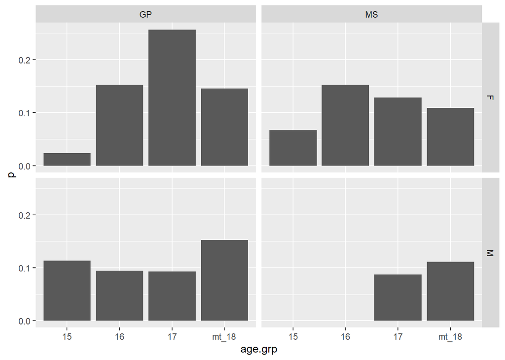

```r
ggplot(data = prop_df) +
  geom_col(mapping = aes(x = age.grp, y = p))+
  facet_grid(sex ~ school)
```

# Q3

```r
check_param <- function(extra.limit, extra.cost, alchol.limit, alchol.cost) {
  if(is.numeric(extra.limit) == TRUE && is.numeric(extra.cost) == TRUE && is.numeric(alchol.limit) == TRUE && is.numeric(alchol.cost) == TRUE) {
    if(extra.limit >= 0 && extra.limit <=20 && alchol.limit >=1 && alchol.limit <=5 && extra.cost >= 0 && alchol.cost >= 0)
      return(TRUE)
    else
    return(FALSE)
  }
  else
    return(FALSE)
}

welfare_func <-function(df, welfare.type = "both", G3.por.limit = 0, extra.cost = 0, Dalc.limit = 1, alchol.cost = 0, ...) {

  type <- welfare.type

  alchol.limit <- Dalc.limit
  extra.limit <- G3.por.limit

  extra.num <- 0
  extra.tot.cost <- 0
  alchol.num <- 0
  alchol.tot.cost <- 0

  add_param <- c()

  if(type == "extra") {
    alchol.limit <- 1
    alchol.cost <- 0
    add_param <- c(alchol.limit, alchol.cost)
  } else if(type == "alchol") {
    extra.limit <- 1
    extra.cost <- 0
    add_param <- c(extra.limit, extra.cost)
  }
  add_param <- c(add_param, ...)

  if(length(add_param) > 0) {
    print("The additional parameters will be regarded.")
  }

  if((type == "both" || type == "extra" || type == "alchol") && check_param(extra.limit, extra.cost, alchol.limit, alchol.cost) == TRUE) {
    if(type == "both" || type == "extra") {
      df <- df %>%
        mutate(extra = ifelse(higher == "yes" & G3.por <= extra.limit, TRUE, FALSE))

      extra.num <- df %>%
        filter(extra == TRUE) %>%
        nrow()

      extra.tot.cost <- extra.num * extra.cost
      if(type == "extra") {
        cat(extra.num, "students will benefit from the extra walfare, and the required cost is", extra.tot.cost, "WON.\n")
      }
    }
    if(type == "both" || type == "alchol") {
      df <- df %>%
        mutate(alchol = ifelse(Walc == 5 & Dalc >= alchol.limit, TRUE, FALSE))

      alchol.num <- df %>%
        filter(alchol == TRUE) %>%
        nrow()
      alchol.tot.cost <- alchol.num * alchol.cost
      if(type == "alchol") {
        cat(alchol.num, "students will benefit from the alchol walfare, and the required cost is", alchol.tot.cost, "WON.")
      }
    }
    if(type == "both") {
      both.num <- df %>%
        filter(extra == TRUE | alchol == TRUE) %>%
        nrow()

      cat(both.num, "students will benefit from the both walfares, and the required cost is", alchol.tot.cost + extra.tot.cost, "WON.")
    }
    invisible(df)
  } else {
    print("VALUE ERROR")
  }
}

#for test

merge_df %>%
  welfare_func(G3.por.limit = 12, welfare.type = "both", Dalc.limit = 3)
```

```
## 317 students will benefit from the both walfares, and the required cost is 0 WON.
```

각 파라미터의 default 값은 아래와 같다.

welfare.type = “both”, G3.por.limit = 0, extra.cost = 0, Dalc.limit = 1, alchol.cost = 0

# TOPIC 2

## Q4

```r
ob_df <- read.table("ObesityDataSet_raw_and_data_sinthetic.csv",sep=",",header=TRUE)
```

```r
ob_df <- ob_df %>%
  mutate(FCVC = case_when(round(FCVC) == 1 ~ "never", round(FCVC) == 2 ~ "sometimes", round(FCVC) == 3 ~ "always"),
         NCP = case_when(NCP < 2.5 ~ "1~2번", NCP >= 2.5 & NCP < 3.5 ~ "3번", NCP >= 3.5 ~ "4번 이상"),
         CH2O = case_when(round(CH2O) == 1 ~ "1리터 미만", round(CH2O) == 2 ~ "1리터 이상 2리터 미만", round(CH2O) == 3 ~ "2리터 이상" ),
         FAF = case_when(round(FAF) == 0 ~ "no", round(FAF) == 1 ~ "1~2 days", round(FAF) == 2 ~ "2~4 days", round(FAF) == 3 ~ "4~5 days"),
         TUE = case_when(round(TUE) == 0 ~ "0~2 hours", round(TUE) == 1 ~ "3~5 hours", round(TUE) == 2 ~ "more than 5 hours"))
```

```r
convert_chr_to_fac <- function(v) {
  if(is.character(v))
    return(factor(v))
  else
    return(v)
}

ob_df <- ob_df %>%
  map_df(convert_chr_to_fac, .x = .)
```

```r
levels(ob_df$FCVC)
```

```
## [1] "always"    "never"     "sometimes"
```

```r
levels(ob_df$CAEC)
```

```
## [1] "Always"     "Frequently" "no"         "Sometimes"
```

```r
levels(ob_df$CALC)
```

```
## [1] "Always"     "Frequently" "no"         "Sometimes"
```

FCVC, CAEC와 CALC는 순서대로 정렬되어 있지 않다.

```r
levels(ob_df$family_history_with_overweight)
```

```
## [1] "no"  "yes"
```

```r
levels(ob_df$FAVC)
```

```
## [1] "no"  "yes"
```

```r
levels(ob_df$SMOKE)
```

```
## [1] "no"  "yes"
```

```r
levels(ob_df$SCC)
```

```
## [1] "no"  "yes"
```

binary variable들은 모두 no, yes 순으로 level이 설정되어 있다.

```r
levels(ob_df$NCP)
```

```
## [1] "1~2번"    "3번"      "4번 이상"
```

```r
levels(ob_df$CH2O)
```

```
## [1] "1리터 미만"            "1리터 이상 2리터 미만" "2리터 이상"
```

```r
levels(ob_df$FAF)
```

```
## [1] "1~2 days" "2~4 days" "4~5 days" "no"
```

no가 앞으로 가는 게 좋을 것이다.

```r
levels(ob_df$TUE)
```

```
## [1] "0~2 hours"         "3~5 hours"         "more than 5 hours"
```

```r
levels(ob_df$MTRANS)
```

```
## [1] "Automobile"            "Bike"                  "Motorbike"
## [4] "Public_Transportation" "Walking"
```

교통수단 사이에 특정한 순서가 있는 것이 아니므로 정렬되어 있지 않다고 말할 근거가 부족하다. 굳이 따지자면 상식적인 측면에서 Automobile, Motorbike, Public_Transportation, Bike, Walking 순서가 나을 것으로 보인다.

```r
levels(ob_df$NObeyesdad)
```

```
## [1] "Insufficient_Weight" "Normal_Weight"       "Obesity_Type_I"
## [4] "Obesity_Type_II"     "Obesity_Type_III"    "Overweight_Level_I"
## [7] "Overweight_Level_II"
```

NObeyesdad도 정렬되어 있지 않다. 저체중 - 정상 - 과제중 - 비만 순서가 올바른 순서이나, 비만과 과체중이 위치가 바뀌어 있다.

```r
ob_df <- ob_df %>%
  mutate(FCVC = fct_relevel(FCVC, c("always", "sometimes", "never")),
                            CAEC = fct_relevel(CAEC, c("Always", "Frequently", "Sometimes", "no")),
                            CALC = fct_relevel(CALC, c("Always", "Frequently", "Sometimes", "no")),
                            FAF = fct_relevel(FAF, c("no", "1~2 days", "2~4 days", "4~5 days")),
                            MTRANS = fct_relevel(MTRANS, c("Automobile", "Motorbike", "Public_Transportation", "Bike", "Walking")),
                            NObeyesdad = fct_relevel(NObeyesdad, c("Insufficient_Weight", "Normal_Weight", "Overweight_Level_I", "Overweight_Level_II", "Obesity_Type_I", "Obesity_Type_II", "Obesity_Type_III")))
```

```r
summary(ob_df)
```

```
##     Gender          Age            Height          Weight
##  Female:1043   Min.   :14.00   Min.   :1.450   Min.   : 39.00
##  Male  :1068   1st Qu.:19.95   1st Qu.:1.630   1st Qu.: 65.47
##                Median :22.78   Median :1.700   Median : 83.00
##                Mean   :24.31   Mean   :1.702   Mean   : 86.59
##                3rd Qu.:26.00   3rd Qu.:1.768   3rd Qu.:107.43
##                Max.   :61.00   Max.   :1.980   Max.   :173.00
##
##  family_history_with_overweight  FAVC             FCVC            NCP
##  no : 385                       no : 245   always   : 996   1~2번   : 492
##  yes:1726                       yes:1866   sometimes:1013   3번     :1470
##                                            never    : 102   4번 이상: 149
##
##
##
##
##          CAEC      SMOKE                         CH2O       SCC
##  Always    :  53   no :2067   1리터 미만           : 485   no :2015
##  Frequently: 242   yes:  44   1리터 이상 2리터 미만:1110   yes:  96
##  Sometimes :1765              2리터 이상           : 516
##  no        :  51
##
##
##
##        FAF                     TUE              CALC
##  no      :720   0~2 hours        :952   Always    :   1
##  1~2 days:776   3~5 hours        :915   Frequently:  70
##  2~4 days:496   more than 5 hours:244   Sometimes :1401
##  4~5 days:119                           no        : 639
##
##
##
##                    MTRANS                   NObeyesdad
##  Automobile           : 457   Insufficient_Weight:272
##  Motorbike            :  11   Normal_Weight      :287
##  Public_Transportation:1580   Overweight_Level_I :290
##  Bike                 :   7   Overweight_Level_II:290
##  Walking              :  56   Obesity_Type_I     :351
##                               Obesity_Type_II    :297
##                               Obesity_Type_III   :324
```

## Q5

```r
ob_df <- ob_df %>%
  mutate(BMI = Weight / Height**2, Weight_Category = cut(BMI, c(0, 18.5, 25, 30, Inf), c("underweight", "normal weight", "overweight", "obesity")))
```

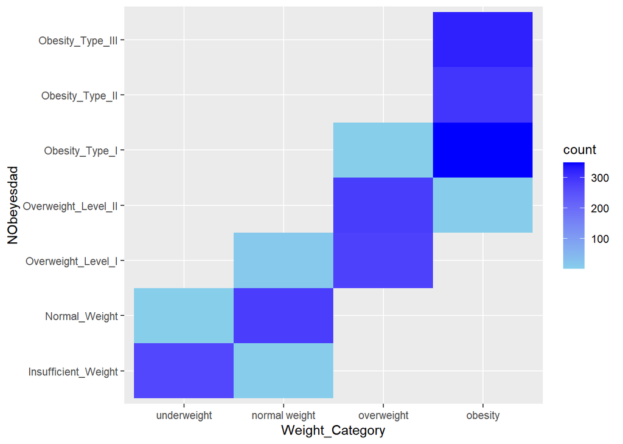

```r
ggplot(ob_df %>% group_by(NObeyesdad, Weight_Category) %>% summarise(count = n())) +
  geom_tile(mapping = aes(y = NObeyesdad, x = Weight_Category, fill = count)) +
  scale_fill_gradient(high = "blue", low = "skyblue")
```

NObeyesdad column과 Weight_Category column이 비슷한 경향성을 보이나 완전히 같지는 않다. Weight_Category가 underweight임에도 NObeyesdad 상으로는 정상 체중인 사람이 있고 이는 normal weight, overweight, obesity level의 경우도 마찬가지이다.

## Q6

```r
cor(ob_df$Height, ob_df$BMI)
```

```
## [1] 0.1317845
```

```r
cor(ob_df$Weight, ob_df$BMI)
```

```
## [1] 0.9348057
```

```r
cor(ob_df$BMI, ob_df$Age)
```

```
## [1] 0.2441631
```

Height와 Age는는 BMI와의 correlation이 작은 반면, Weight는는 굉장히 높다.

우선 음식과 관련 있는 변수 중 3개와 family_history_with_overweight 변수를 함께 살펴보자.

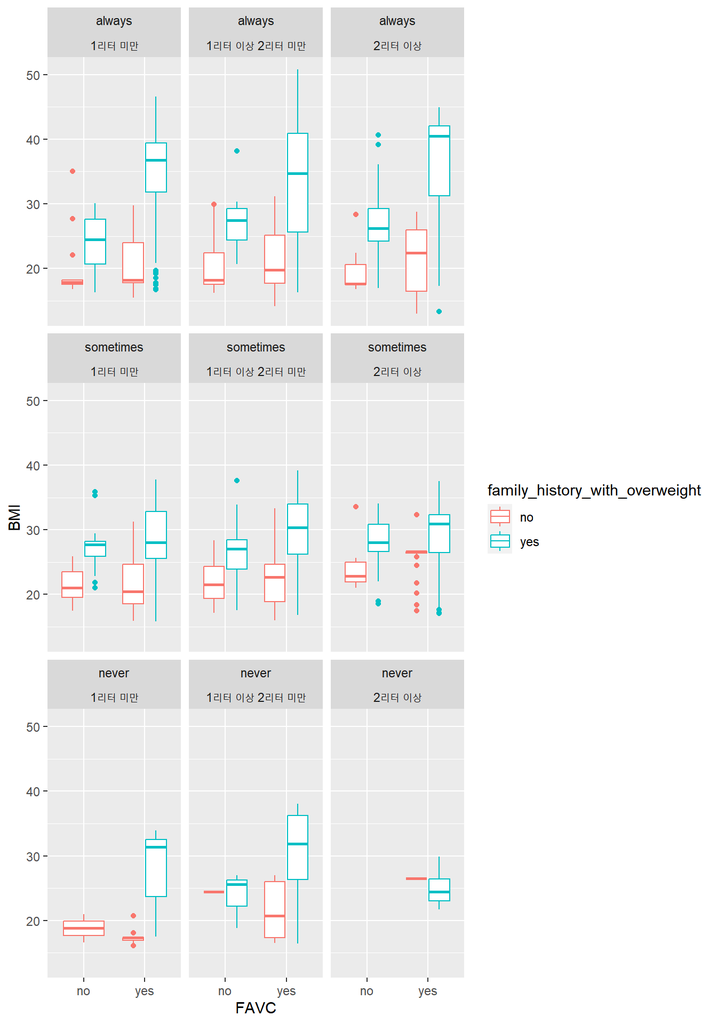

```r
ggplot(ob_df) +
  geom_boxplot(mapping = aes(x = FAVC, y = BMI, col = family_history_with_overweight)) +
  facet_wrap(~FCVC + CH2O)
```

고칼로리 음식을 자주 먹는 경우 (FAVC) BMI가 높은 쪽에 데이터가 몰려 있음을 확인할 수 있다. 또한, 가족력이 있는 경우에 (family_history_with_overweight) 파란색 점과 붉은색 점이 대체로 분리되어 있는 것을 볼 수 있고 특히 파란색의 경우 BMI가 높은 쪽에 몰려 있다. 그리고 채소를 먹는 횟수 (FCVC)에 대해서 그래프는 FCVC가 클수록 BMI가 높은 사람도 많다는 결과를 보여주는데 (2열을 보면 그 경향성이 두드러지게 드러난다.), 이는 상식에 반하는 결과이다. 이 경우 채소를 많이 먹는 사람이 먹는 양이 많은 것으로 해석해볼 수 있을 것이다. 그러므로 BMI에 유의하게 작용한다고 볼 수는 있을 것이다. 전반적으로 물을 많이 마실수록 (CH2O가 커질수록) BMI가 높아짐을 확인할 수 있다. FCVC와 CH2O가 달라도 그래프의 양상이 대부분 비슷하기 때문에, 이들 간 상관관계는 높지 않을 것으로 생각된다.

한편, MTRANS 변수에서,

```r
lm_model <- lm(BMI~MTRANS, data = ob_df)
```

```r
sum((predict(lm_model, ob_df) - ob_df$BMI)^2)
```

```
## [1] 132682.3
```

```r
n_ob_df <- ob_df %>%
  mutate(nMTRANS = case_when(MTRANS == "Automobile" | MTRANS == "Motorbike" ~ "Auto", MTRANS == "Public_Transportation" ~ "Public", MTRANS == "Bike" | MTRANS == "Walking" ~ "Walking"))
```

```r
lm_model <- lm(BMI~nMTRANS, data = n_ob_df)
```

```r
sum((predict(lm_model, n_ob_df) - n_ob_df$BMI)^2)
```

```
## [1] 132822.5
```

Motorbike와 Bike level을 다른 변수와 합쳤을 때 선형 회귀의 에러의 증가 폭이 크지 않으므로, 모델의 복잡도 및 분산을 줄이기 위해 코드에 나와있듯이 총 3개의 level로만 구성된 새로운 nMTRANS 변수를 만드는 것이 나을 것이다.

```r
summary(n_ob_df$BMI[n_ob_df$nMTRANS == "Auto"])
```

```
##    Min. 1st Qu.  Median    Mean 3rd Qu.    Max.
##   16.65   25.75   28.95   29.11   33.33   40.64
```

```r
summary(n_ob_df$BMI[n_ob_df$nMTRANS == "Public"])
```

```
##    Min. 1st Qu.  Median    Mean 3rd Qu.    Max.
##   13.00   24.24   28.98   30.11   36.58   50.81
```

```r
summary(n_ob_df$BMI[n_ob_df$nMTRANS == "Walking"])
```

```
##    Min. 1st Qu.  Median    Mean 3rd Qu.    Max.
##   13.29   21.15   23.84   23.83   25.67   38.53
```

summary() 함수를 통해 nMTRANS별 분포를 살펴보자. Walking은 다른 레벨과 비교해서 분포에 큰 차이가 있어보이나, 앞에 두 개 (Auto, Public)은 비슷해 보인다. t-test를 통해 확인해보자.

```r
t.test(BMI ~ nMTRANS, n_ob_df %>% filter(nMTRANS != "Walking"))
```

```
##
##  Welch Two Sample t-test
##
## data:  BMI by nMTRANS
## t = -2.8366, df = 1061.3, p-value = 0.004647
## alternative hypothesis: true difference in means between group Auto and group Public is not equal to 0
## 95 percent confidence interval:
##  -1.6950513 -0.3088555
## sample estimates:
##   mean in group Auto mean in group Public
##             29.10776             30.10971
```

데이터 개수가 많기 때문에 평균 차이가 적어보여도 그 차이가 유의하다는 결론을 보여준다.

Gender, SMOKE와 CALC, SCC 변수에 대해서도 비슷한 방식의 EDA를 수행하자.

```r
summary(ob_df$BMI[ob_df$Gender == "Male"])
```

```
##    Min. 1st Qu.  Median    Mean 3rd Qu.    Max.
##   13.29   25.57   28.91   29.28   35.22   49.47
```

```r
summary(ob_df$BMI[ob_df$Gender == "Female"])
```

```
##    Min. 1st Qu.  Median    Mean 3rd Qu.    Max.
##   13.00   22.36   28.47   30.13   40.08   50.81
```

```r
t.test(BMI ~ Gender, ob_df)
```

```
##
##  Welch Two Sample t-test
##
## data:  BMI by Gender
## t = 2.4282, df = 1823.5, p-value = 0.01527
## alternative hypothesis: true difference in means between group Female and group Male is not equal to 0
## 95 percent confidence interval:
##  0.1633912 1.5358581
## sample estimates:
## mean in group Female   mean in group Male
##             30.13000             29.28038
```

p-value도 0.05보다 낮고 무엇보다 그룹의 분산에 차이가 크기 때문에 Gender는 유의하다고 볼 수 있다.

```r
summary(ob_df$BMI[ob_df$SMOKE == "yes"])
```

```
##    Min. 1st Qu.  Median    Mean 3rd Qu.    Max.
##   18.22   24.23   29.69   29.66   36.09   41.91
```

```r
summary(ob_df$BMI[ob_df$SMOKE == "no"])
```

```
##    Min. 1st Qu.  Median    Mean 3rd Qu.    Max.
##   13.00   24.34   28.72   29.70   35.99   50.81
```

```r
t.test(BMI ~ SMOKE, ob_df)
```

```
##
##  Welch Two Sample t-test
##
## data:  BMI by SMOKE
## t = 0.045462, df = 45.762, p-value = 0.9639
## alternative hypothesis: true difference in means between group no and group yes is not equal to 0
## 95 percent confidence interval:
##  -1.987413  2.079248
## sample estimates:
##  mean in group no mean in group yes
##          29.70112          29.65520
```

p-value가 1에 가까우므로, SMOKE에 따른 BMI의 평균 차이는 없다고 볼 수 있다.

```r
anova_fit <- aov(ob_df$BMI ~ ob_df$CALC)
summary(anova_fit)
```

```
##               Df Sum Sq Mean Sq F value Pr(>F)
## ob_df$CALC     3   7538  2512.6    41.4 <2e-16 ***
## Residuals   2107 127885    60.7
## ---
## Signif. codes:  0 '***' 0.001 '**' 0.01 '*' 0.05 '.' 0.1 ' ' 1
```

anova 적합 시 CALC는 BMI에 확연한 영향을 미친다는 것을 알 수 있다.

```r
t.test(BMI ~ SCC, ob_df)
```

```
##
##  Welch Two Sample t-test
##
## data:  BMI by SCC
## t = 15.765, df = 133.7, p-value < 2.2e-16
## alternative hypothesis: true difference in means between group no and group yes is not equal to 0
## 95 percent confidence interval:
##  6.195710 7.973315
## sample estimates:
##  mean in group no mean in group yes
##          30.02233          22.93782
```

SCC는 평균 차이가 무려 7이나 나고 p-value 값도 0에 가까움을 볼 수 있다. 즉, SCC는 BMI에 매우 유의하게 작용하는 변수이다.

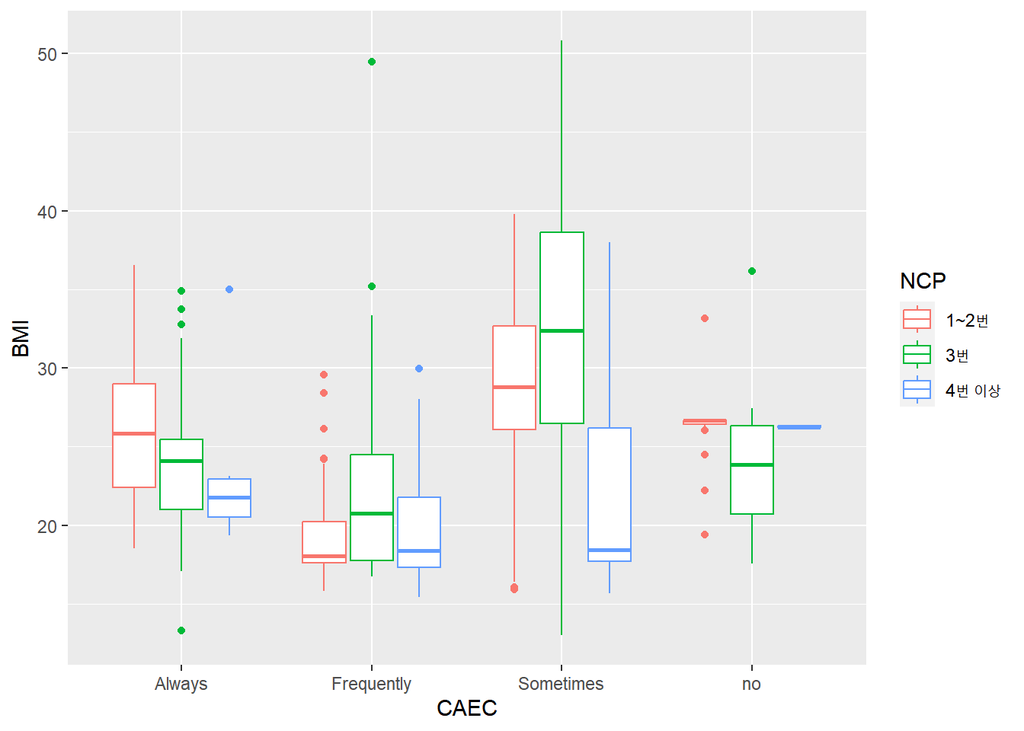

```r
ggplot(ob_df) +
  geom_boxplot(mapping = aes(x = CAEC, y = BMI, col = NCP))
```

간식 섭취 빈도에 따른 BMI는 단조 증가 혹은 감소하는 경향성을 갖기 보다는 증감이 왔다갔다 하는 모습을 보인다. Frequently에서 가장 작은 값을 갖고 Sometimes에서 가장 높은 값을 갖는다. 즉, 간식이 BMI에 영향을 준다기보다는 단지 그 카테고리에 해당되는 사람들이 다른 x값들에 대해 차이를 갖고 표본 수에 큰 차이가 나기 때문에 위와 같은 결과가 나온 것으로 생각된다. 그래서 CAEC에 영향을 줄 수 있는 변수인 NCP를 같이 도식화했다. 일반적인 경우에는 밥을 3번 먹는 사람이 가장 많으나, 간식을 항상 먹는 (Always) 사람들의 경우 간식의 영향으로 밥을 1~2번만 먹는 경우가 많다. 즉 NCP와 CAEC는 어느 정도 상관관계가 존재한다. NCP는 3>1~2>4의 순서로 BMI가 크다. 대부분의 사람들일 밥을 3번 먹는다는 점 (즉 표본 수의 불균형)이 직관에 반하는 결과를 야기한 것으로 보인다. 그러므로 표본 수의 불균형으로 인하여 결과가 상식에 반하기 때문에 이 두 변수는 고려하지 않는 것이 좋을 것 같다.

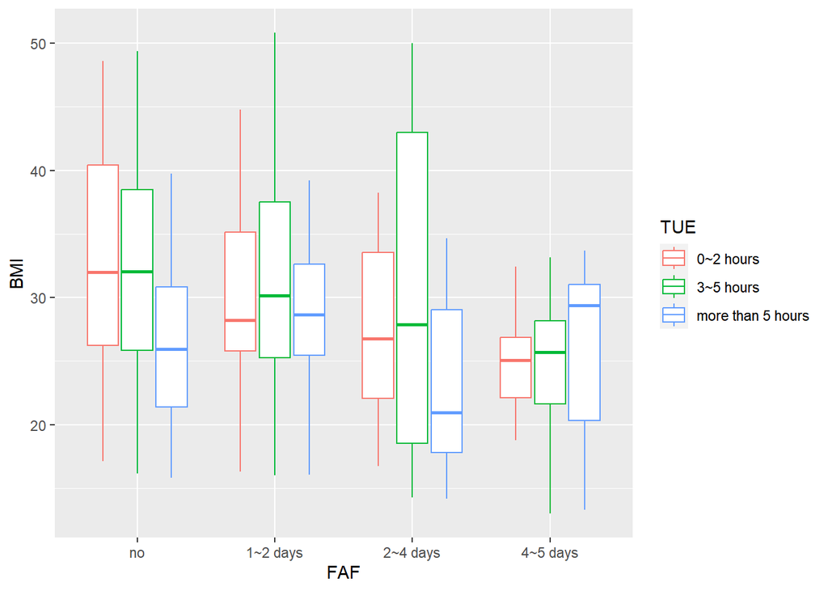

```r
ggplot(ob_df) +
  geom_boxplot(mapping = aes(x = FAF, y = BMI, col = TUE))
```

```r
summary(ob_df$BMI[ob_df$TUE=="0~2 hours"])
```

```
##    Min. 1st Qu.  Median    Mean 3rd Qu.    Max.
##   16.33   25.35   28.73   29.68   35.52   48.57
```

```r
summary(ob_df$BMI[(ob_df$TUE=="3~5 hours") | (ob_df$TUE == "more than 5 hours")])
```

```
##    Min. 1st Qu.  Median    Mean 3rd Qu.    Max.
##   13.00   23.08   28.61   29.72   36.67   50.81
```

NObeyesdad는 Q5에서 BMI와 연관성이 있음을 밝혔다.

## Q7

```r
set.seed(1234)
temp_ob <- n_ob_df %>%
  initial_split(0.8)
train <- temp_ob %>%
  training()
test <- temp_ob %>%
  testing()
```

BMI에 영향을 준다고 판단되는 변수는 다음과 같다.

Gender, Weight, family_history_with_overweight, FAVC, FCVC, CH2O, nMTRANS, CALC, SCC, FAF, NObeyesdad  
이들로 모델을 적합시키면,

```r
lm_fit <- lm(BMI ~ Weight + family_history_with_overweight + FAVC + FCVC + CH2O + nMTRANS + CALC + SCC + FAF + NObeyesdad + Gender, data = train)
pred <- lm_fit$fitted.values
mean((pred - train$BMI)^2)
```

```
## [1] 1.379011
```

train set의 mse는 1.379가 나왔다. BMI의 스케일이 20~50 정도임을 고려하면 매우 적은 오차임을 알 수 있다.

```r
pred <- predict(lm_fit, test)
mean((pred - test$BMI)^2)
```

```
## [1] 1.511637
```

valid set의 mse도 1.511로 매우 작은 값이 나왔다.

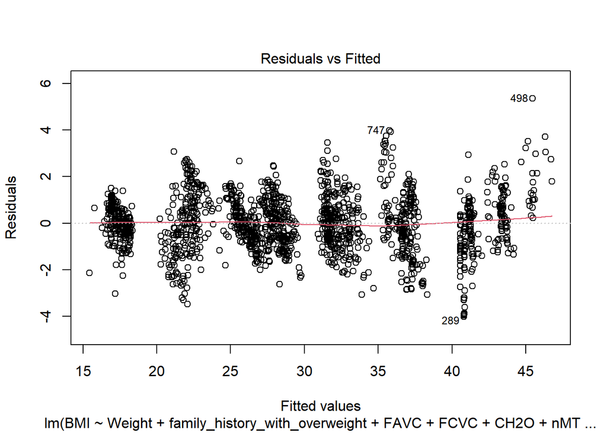

```r
plot(lm_fit, which = 1)
```

residual이 0 주변에 균등하게 분포되어 있으므로로 적합이 잘 되었다고 볼 수 있다.

interaction을 고려하기 위해 EDA를 추가로 수행해보자.  
continuous 변수인 Weight와 categorical 변수 간의 interaction을 파악하기 위해 여러 plot을 그려본 결과, Weight와 Gender 사이 interaction이 유의하게 나오는 것을 알 수 있었다.

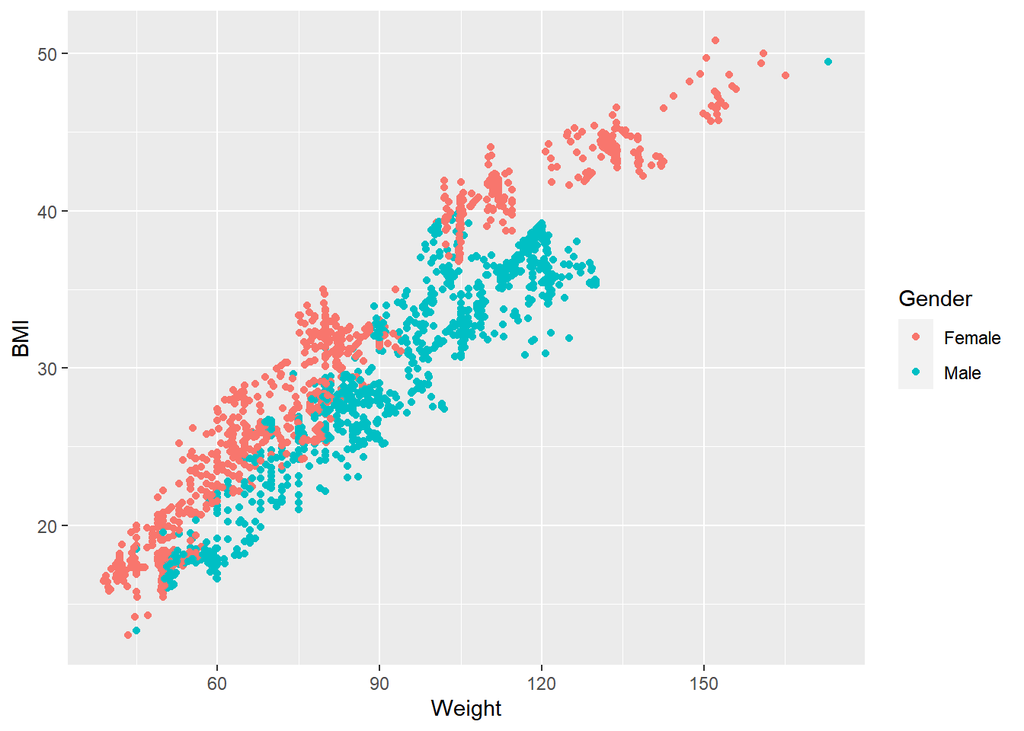

```r
ggplot(n_ob_df) +
  geom_point(mapping = aes(x = Weight, y = BMI, col = Gender))
```

```r
lm_fit_inter <- lm(BMI ~ Gender * Weight + family_history_with_overweight + FAVC + FCVC + CH2O + nMTRANS + CALC + SCC + FAF + NObeyesdad, data = train)
pred <- lm_fit_inter$fitted.values
mean((pred - train$BMI)^2)
```

```
## [1] 1.321905
```

```r
pred <- predict(lm_fit_inter, test)
mean((pred - test$BMI)^2)
```

```
## [1] 1.436453
```

MSE가 interaction term이 없을 때에 비해서 확연히 줄어듦을 확인할 수 있었다.

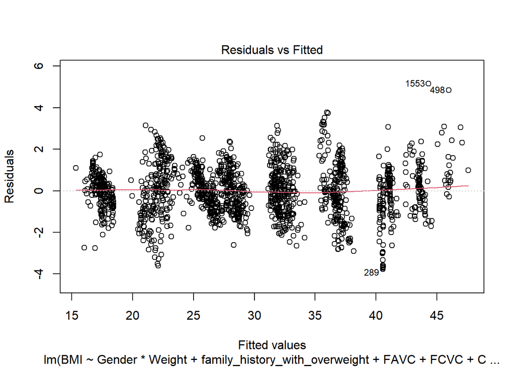

```r
plot(lm_fit_inter, which = 1)
```

모델 역시 잘 적합되었음을 plot을 통해 확인할 수 있다.

# TOPIC 3

## Q8

```r
#int_columns <- c("instant", "yr", "mnth", "hr")
hr_df <- read_csv("hour.csv", col_types = (cols(instant = col_integer(),
                                                season = readr::col_factor(),
                                                yr = col_integer(),
                                                mnth = col_integer(),
                                                hr = col_integer(),
                                                holiday = readr::col_factor(),
                                                weekday = readr::col_factor(),
                                                workingday = col_integer(),
                                                weathersit = readr::col_factor(),
                                                temp = col_double(),
                                                atemp = col_double(),
                                                hum = col_double(),
                                                windspeed = col_double(),
                                                casual = col_integer(),
                                                registered = col_integer(),
                                                cnt = col_integer())))
```

```r
hr_df <- hr_df %>%
  mutate(season = recode_factor(season, "1" = "Win", "2" = "Spr", "3" = "Sum", "4" = "Aut"),
         weekday = recode_factor(weekday, "0" = "Sun", "1" = "Mon", "2" = "Tue", "3" = "Wed", "4" = "Thu", "5" = "Fri", "6" = "Sat"),
         weathersit = recode_factor(weathersit, "1" = "Clear", "2" = "Cloudy", "3" = "Light", "4" = "Heavy"))
```

```r
str(hr_df)
```

```
## tibble [17,379 × 17] (S3: tbl_df/tbl/data.frame)
##  $ instant   : int [1:17379] 1 2 3 4 5 6 7 8 9 10 ...
##  $ dteday    : Date[1:17379], format: "2011-01-01" "2011-01-01" ...
##  $ season    : Factor w/ 4 levels "Win","Spr","Sum",..: 1 1 1 1 1 1 1 1 1 1 ...
##  $ yr        : int [1:17379] 0 0 0 0 0 0 0 0 0 0 ...
##  $ mnth      : int [1:17379] 1 1 1 1 1 1 1 1 1 1 ...
##  $ hr        : int [1:17379] 0 1 2 3 4 5 6 7 8 9 ...
##  $ holiday   : Factor w/ 2 levels "0","1": 1 1 1 1 1 1 1 1 1 1 ...
##  $ weekday   : Factor w/ 7 levels "Sun","Mon","Tue",..: 7 7 7 7 7 7 7 7 7 7 ...
##  $ workingday: int [1:17379] 0 0 0 0 0 0 0 0 0 0 ...
##  $ weathersit: Factor w/ 4 levels "Clear","Cloudy",..: 1 1 1 1 1 2 1 1 1 1 ...
##  $ temp      : num [1:17379] 0.24 0.22 0.22 0.24 0.24 0.24 0.22 0.2 0.24 0.32 ...
##  $ atemp     : num [1:17379] 0.288 0.273 0.273 0.288 0.288 ...
##  $ hum       : num [1:17379] 0.81 0.8 0.8 0.75 0.75 0.75 0.8 0.86 0.75 0.76 ...
##  $ windspeed : num [1:17379] 0 0 0 0 0 0.0896 0 0 0 0 ...
##  $ casual    : int [1:17379] 3 8 5 3 0 0 2 1 1 8 ...
##  $ registered: int [1:17379] 13 32 27 10 1 1 0 2 7 6 ...
##  $ cnt       : int [1:17379] 16 40 32 13 1 1 2 3 8 14 ...
```

## Q9

```r
tot_hr_df <- hr_df %>%
  group_by(dteday) %>%
  summarise(total = sum(cnt))
```

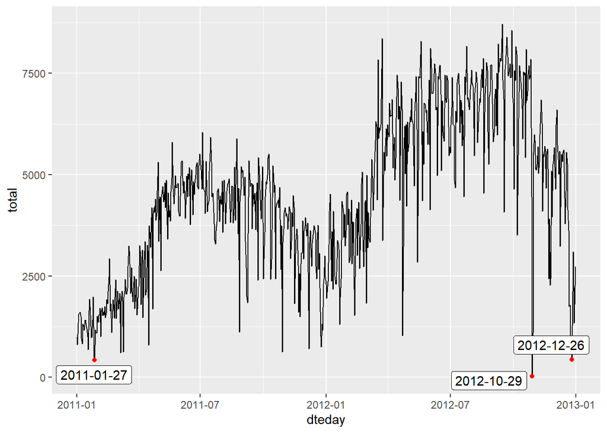

```r
ggplot(tot_hr_df) +
  geom_line(mapping = aes(x = dteday, y = total)) +
  ggrepel::geom_label_repel(mapping = aes(x = dteday, y = total, label = format(dteday)), data = tot_hr_df %>% filter(total < 500)) +
  geom_point(mapping = aes(x = dteday, y = total, label = format(dteday)), data = tot_hr_df %>% filter(total < 500), col = "red")
```

```r
hr_df %>%
  filter(dteday == ymd(20110127))
```

```
## # A tibble: 8 × 17
##   instant dteday     season    yr  mnth    hr holiday weekday workingday
##     <int> <date>     <fct>  <int> <int> <int> <fct>   <fct>        <int>
## 1     588 2011-01-27 Win        0     1    16 0       Thu              1
## 2     589 2011-01-27 Win        0     1    17 0       Thu              1
## 3     590 2011-01-27 Win        0     1    18 0       Thu              1
## 4     591 2011-01-27 Win        0     1    19 0       Thu              1
## 5     592 2011-01-27 Win        0     1    20 0       Thu              1
## 6     593 2011-01-27 Win        0     1    21 0       Thu              1
## 7     594 2011-01-27 Win        0     1    22 0       Thu              1
## 8     595 2011-01-27 Win        0     1    23 0       Thu              1
## # ℹ 8 more variables: weathersit <fct>, temp <dbl>, atemp <dbl>, hum <dbl>,
## #   windspeed <dbl>, casual <int>, registered <int>, cnt <int>
```

```r
hr_df %>%
  filter(dteday == ymd(20121029))
```

```
## # A tibble: 1 × 17
##   instant dteday     season    yr  mnth    hr holiday weekday workingday
##     <int> <date>     <fct>  <int> <int> <int> <fct>   <fct>        <int>
## 1   15884 2012-10-29 Aut        1    10     0 0       Mon              1
## # ℹ 8 more variables: weathersit <fct>, temp <dbl>, atemp <dbl>, hum <dbl>,
## #   windspeed <dbl>, casual <int>, registered <int>, cnt <int>
```

0시의 데이터만 존재한다. 허리케인 Sandy가 이 날 뉴욕을 강타한 사건 때문으로 보인다.

```r
hr_df %>%
  filter(dteday == ymd(20121226))
```

```
## # A tibble: 24 × 17
##    instant dteday     season    yr  mnth    hr holiday weekday workingday
##      <int> <date>     <fct>  <int> <int> <int> <fct>   <fct>        <int>
##  1   17236 2012-12-26 Win        1    12     0 0       Wed              1
##  2   17237 2012-12-26 Win        1    12     1 0       Wed              1
##  3   17238 2012-12-26 Win        1    12     2 0       Wed              1
##  4   17239 2012-12-26 Win        1    12     3 0       Wed              1
##  5   17240 2012-12-26 Win        1    12     4 0       Wed              1
##  6   17241 2012-12-26 Win        1    12     5 0       Wed              1
##  7   17242 2012-12-26 Win        1    12     6 0       Wed              1
##  8   17243 2012-12-26 Win        1    12     7 0       Wed              1
##  9   17244 2012-12-26 Win        1    12     8 0       Wed              1
## 10   17245 2012-12-26 Win        1    12     9 0       Wed              1
## # ℹ 14 more rows
## # ℹ 8 more variables: weathersit <fct>, temp <dbl>, atemp <dbl>, hum <dbl>,
## #   windspeed <dbl>, casual <int>, registered <int>, cnt <int>
```

2012년 12월 26일의 경우는 데이터는 정상적으로 존재하나 유독 다른 날보다 대여량이 적다. 위키피디아에 따르면, ‘A moderate severe weather outbreak pounds several southern U.S. states on Christmas Day, including Texas, Alabama, Mississippi and Louisiana.’ 라고 한다. 실제로 그런지 확인해보자.

```r
low_temp_days <- hr_df %>%
  filter(atemp <= 0.2) %>%
  dplyr::select(dteday) %>%
  unique()
```

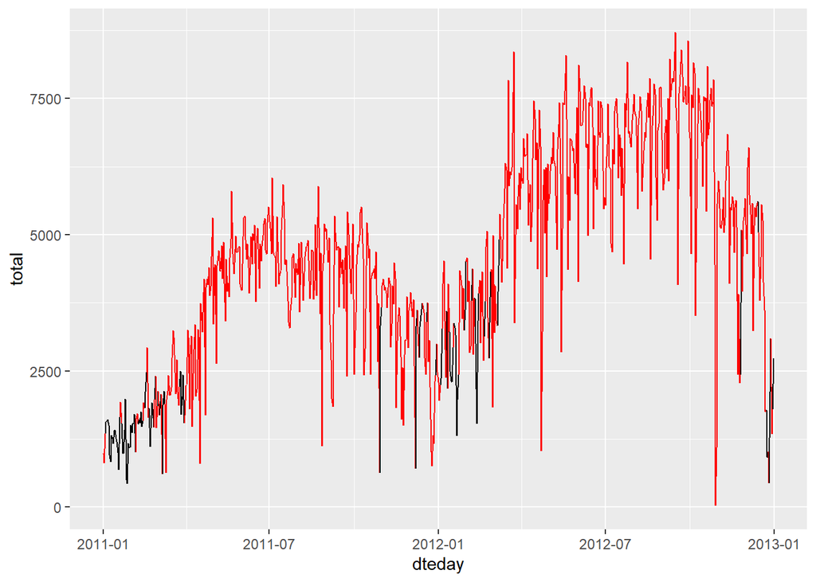

```r
ggplot(tot_hr_df) +
  geom_line(mapping = aes(x = dteday, y = total), col = ifelse(tot_hr_df$dteday %in% low_temp_days$dteday, "black", "red"))
```

```r
# atemp <= 0.2인 때 체크해보자
```

자전거 대여량과 온도의 연관성을 찾기 위해 체감온도가 0.2 이하인 날들은 검은색으로 표시하였다. 그 경우 자전거 대여량이 적은 날들은 거의 체감온도가 낮음을 확인할 수 있었다.

```r
ymd("20121226") %in% low_temp_days$dteday
```

```
## [1] TRUE
```

그리고 2012-12-26 역시 체감온도가 매우 낮은 날에 해당한다. 따라서 온도의 영향으로 인해 대여량이 급격하게 줄어들었을 것이라 추측할 수 있다.

## Q10

```r
l_hr_df <- hr_df %>%
  pivot_longer(cols = casual:registered,
               names_to = "is_registered",
               values_to = "cond_count")
```

```r
l_hr_df %>%
  group_by(hr, is_registered, season, holiday) %>%
  summarise(mean = mean(cond_count))
```

```
## # A tibble: 384 × 5
## # Groups:   hr, is_registered, season [192]
##       hr is_registered season holiday  mean
##    <int> <chr>         <fct>  <fct>   <dbl>
##  1     0 casual        Win    0        3.35
##  2     0 casual        Win    1        4.43
##  3     0 casual        Spr    0       12.2
##  4     0 casual        Spr    1       20
##  5     0 casual        Sum    0       16.1
##  6     0 casual        Sum    1       38.8
##  7     0 casual        Aut    0        7.94
##  8     0 casual        Aut    1        6.33
##  9     0 registered    Win    0       24.1
## 10     0 registered    Win    1       21.7
## # ℹ 374 more rows
```

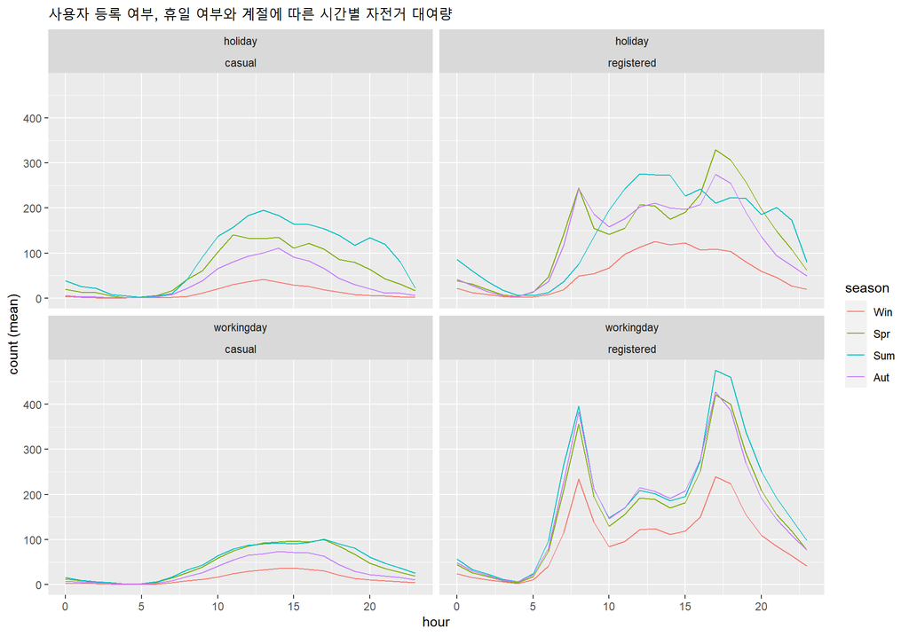

```r
ggplot(l_hr_df %>%
  mutate(holiday = ifelse(holiday == 0, "workingday", "holiday")) %>%
  group_by(hr, is_registered, season, holiday) %>%
  summarise(mean = mean(cond_count))) +
  geom_line(mapping = aes(x = hr, y = mean, col = season)) +
  facet_wrap(~holiday + is_registered) +
  labs(title = "사용자 등록 여부, 휴일 여부와 계절에 따른 시간별 자전거 대여량") +
  xlab("hour") +
  ylab("count (mean)")
```

요일별 그래프보다 휴일 여부에 따른 그래프가 정보 손실은 적으면서 더 간편한 그래프를 보여준다는 점에서 weekday 변수는 사용하지 않고 holiday 변수 사용하였다. 그리고 season과 사용자 등록 여부 변수도 추가하여 시간별 자전거 대여량의 평균에 대한 그래프를 그렸다.  
우선 casual user의 경우, 휴일인지 아닌지에 상관없이 Summer>Spring>Autumn>Winter의 순서대로 자전거 대여량이 많았다. 즉, 온도가 높을수록 자전거를 타는 경향이 높다는 것이다. 그리고 주로 낮~오후 시간대 (10시~3시) 때 자전거를 대여하는 사람이 가장 많았다. 그릐고 휴일에 자전거를 대여하는 사람이 더 많았다.  
한편, registered user의 경우는 평일에는 계절에 상관없이 그래프가 모두 비슷한 개형을 보인다. 모두 출퇴근 시간대에 그래프가 피크를 찍는다. 그러나, 휴일의 경우는 봄과 가을에는 출퇴근 시간에 피크를 찍기는 하지만 그 정도가 평일인 경우보다 작다. 그리고 여름과 겨울의 그래프는 casual user와 비슷한 개형을 보인다.

```r
cor(hr_df$temp, hr_df$atemp)
```

```
## [1] 0.9876721
```

온독와 체감 온도 사이의 상관관계가 매우 높으므로, 온도에 대한 EDA를 수행한다면 둘 중 한 변수에 대해서만 EDA를 진행할 것이다.

```r
hr_df %>%
  group_by(season) %>%
  summarise(mean = mean(temp))
```

```
## # A tibble: 4 × 2
##   season  mean
##   <fct>  <dbl>
## 1 Win    0.299
## 2 Spr    0.545
## 3 Sum    0.706
## 4 Aut    0.423
```

```r
season_num_df <- hr_df %>%
  mutate(season_num = case_when(season == "Spr" ~ 3, season == "Sum" ~ 4, season == "Aut" ~ 2, season == "Win" ~ 1)) %>%
  dplyr::select(season_num)
cor(hr_df$temp, season_num_df$season_num)
```

```
## [1] 0.7823179
```

그런데 season과 temp 사이 상관계수를 계산해보면 0.78로 강한 상관을 보인다는 것을 알 수 있다. 이는 곧 그래프의 개형도 비슷할 것을 의미하므로, 온도에 따른 시간대별 자전거 대여량 그래프는 계절에 따른 시간대별 자전거 대여량 그래프를 대체할 수 있다. (그래프 제한이 없다면 온도에 따른 그래프도 그리는 것이 좋을 것이다.)

```r
Q_hum <- c(0, quantile(hr_df$hum, 0.25), quantile(hr_df$hum, 0.5), quantile(hr_df$hum, 0.75), 1)

hr_df %>%
  filter(hum != 0) %>% # humid = 0인 행은 오류일 가능성이 높으므로.
  mutate(hum_cut = cut(hum, Q_hum, label = c("~25%", "25%~50%", "50%~75%", "75%~"), include.lowest = TRUE)) %>%
  group_by(hum_cut, hr, weathersit) %>%
  summarise(mean = mean(cnt))
```

```
## # A tibble: 280 × 4
## # Groups:   hum_cut, hr [96]
##    hum_cut    hr weathersit  mean
##    <fct>   <int> <fct>      <dbl>
##  1 ~25%        0 Clear      49.3
##  2 ~25%        0 Cloudy     43.6
##  3 ~25%        1 Clear      25.4
##  4 ~25%        1 Cloudy     38.1
##  5 ~25%        2 Clear      18.8
##  6 ~25%        2 Cloudy     25.7
##  7 ~25%        3 Clear       8.73
##  8 ~25%        3 Cloudy     10.9
##  9 ~25%        4 Clear       3.97
## 10 ~25%        4 Cloudy      5.88
## # ℹ 270 more rows
```

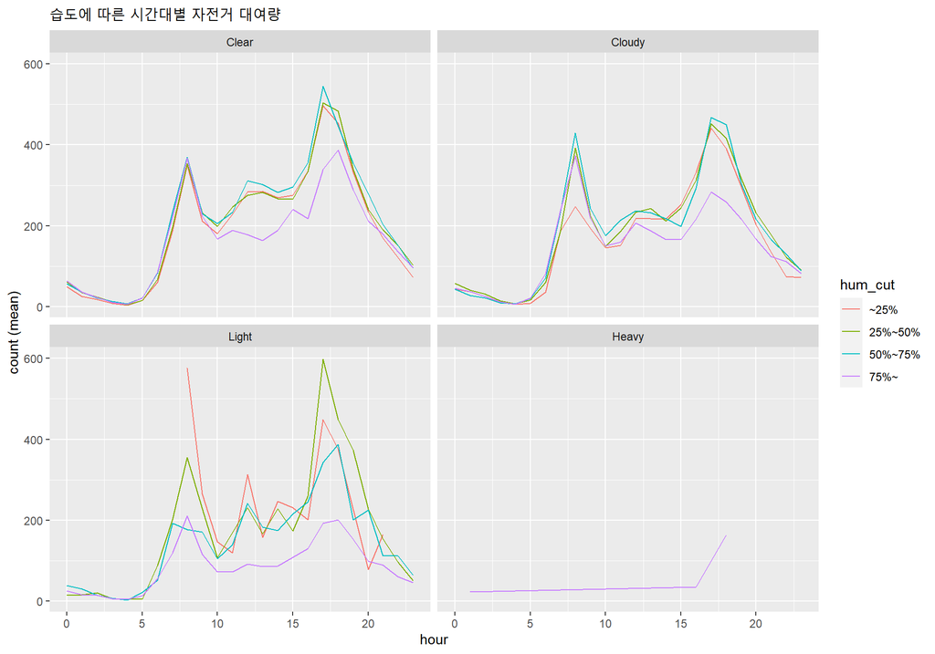

```r
ggplot(hr_df %>%
  filter(hum != 0) %>% # humid = 0인 행은 오류일 가능성이 높으므로.
  mutate(hum_cut = cut(hum, Q_hum, label = c("~25%", "25%~50%", "50%~75%", "75%~"), include.lowest = TRUE)) %>%
  group_by(hum_cut, hr, weathersit) %>%
  summarise(mean = mean(cnt))) +
  geom_line(mapping = aes(x = hr, y = mean, col = hum_cut)) +
  facet_wrap(~weathersit, nrow = 2) +
  labs(title = "습도에 따른 시간대별 자전거 대여량") +
  xlab("hour") +
  ylab("count (mean)")
```

습도에 영향을 미치는 변수로 운량이 있으므로 facet에 운량을 넣어서 습도에 따른 시간대별 자전거 대여량을 그려보았다.  
운량이 Clear와 Cloudy일 때는 습도의 percentile이 75% 정도일 때까지에서는 자전거 대여량에 큰 차이가 없으나 습도의 percentile이 75% 이상인 경우 10시~20시 정도의 시간대에서는 자전거 대여량이 다른 경우보다 줄어듦을 관찰할 수 있었다. (그 외의 시간대는 자전거를 타지 않는 새벽 or 심야이거나, 출근 시간대이다. 이 경우들은 자전거 대여 여부가 습도에 큰 관계가 없을 것이다.) 운량이 Light일 때,  
출근 시간대: 습도가 낮을수록 대여량이 높다.  
낮~오후 시간대: 75% 이상일 때를 제외하고는 비슷하다.  
퇴근 시간대: 습도가 25%~50%일 때 대여량이 가장 많고 75%~일 때 역시나 가장 적은 대여량을 보인다.  
Light일 때 일관적인 경향성을 보이지 않는 이유는 데이터 자체가 적어서 그런 것으로 생각된다. (아래 분할표 참고) 전체적으로 운량이 증가할수록 대여량도 줄어드는 경향성을 보인다.

```r
hr_df %>%
  filter(hum != 0) %>% # humid = 0인 행은 오류일 가능성이 높으므로.
  mutate(hum_cut = cut(hum, Q_hum, label = c("~25%", "25%~50%", "50%~75%", "75%~"), include.lowest = TRUE)) %>%
  dplyr::select(weathersit, hum_cut) %>%
  table()
```

```
##           hum_cut
## weathersit ~25% 25%~50% 50%~75% 75%~
##     Clear  3937    3084    2759 1633
##     Cloudy  589    1055    1273 1625
##     Light    21      96     230 1052
##     Heavy     0       0       0    3
```

```r
# hr_df %>%
#   filter(hum != 0) %>%
#   mutate(hum_cut = cut(hum, Q_hum, label = c("~25%", "25%~50%", "50%~75%", "75%~"), include.lowest = TRUE)) %>%
#   group_by(weathersit, hum_cut) %>%
#   summarise(n = n()) %>%
#   table()
```

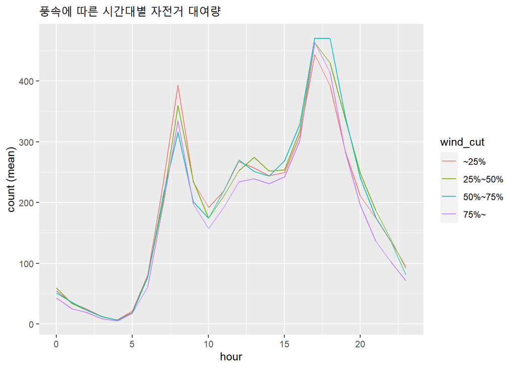

```r
Q_wind <- c(0, quantile(hr_df$windspeed, 0.25), quantile(hr_df$windspeed, 0.5), quantile(hr_df$windspeed, 0.75), 1)

ggplot(hr_df %>%
  mutate(wind_cut = cut(windspeed, Q_wind, label = c("~25%", "25%~50%", "50%~75%", "75%~"), include.lowest = TRUE)) %>%
  group_by(wind_cut, hr) %>%
  summarise(mean = mean(cnt))) + geom_line(mapping = aes(x = hr, y = mean, col = wind_cut)) +
  labs(title = "풍속에 따른 시간대별 자전거 대여량") +
  xlab("hour") +
  ylab("count (mean)")
```

풍속에 따라서는 대여량이 시간대별로 큰 차이를 보이지 않는다.

# Topic 4

## Q11

workclass (X2), occupation (X7), native-country (X14)가 결측치를 갖고 있다.  
그리고 그 결측값은 모두 “?”로 표시되어 있다.

```r
adult_df <- read_csv("adult.data", col_names = FALSE, na = c("?", "NA"))
adult_names <- read_csv("adult.names")
colnames(adult_names) <- c("col")

adult_names <- tail(adult_names, 14)

column_names <- adult_names %>%
  mutate(extracted = str_extract_all(col, "^[a-z|-]+:")) %>%
  unnest(extracted) %>%
  mutate(extracted = str_replace_all(extracted, c(":" = "", "-" = "_"))) %>%
  dplyr::select(extracted)

column_names <- column_names$extracted

colnames(adult_df) <- column_names
colnames(adult_df)[15] <- "salary"
```

```r
convert_chr_to_fac <- function(v) {
  if(is.character(v))
    return(factor(v))
  else
    return(v)
}


adult_df <- adult_df %>%
  map_df(convert_chr_to_fac, .x = .)
```

```r
str(adult_df)
```

```
## tibble [32,561 × 15] (S3: tbl_df/tbl/data.frame)
##  $ age           : num [1:32561] 39 50 38 53 28 37 49 52 31 42 ...
##  $ workclass     : Factor w/ 8 levels "Federal-gov",..: 7 6 4 4 4 4 4 6 4 4 ...
##  $ fnlwgt        : num [1:32561] 77516 83311 215646 234721 338409 ...
##  $ education     : Factor w/ 16 levels "10th","11th",..: 10 10 12 2 10 13 7 12 13 10 ...
##  $ education_num : num [1:32561] 13 13 9 7 13 14 5 9 14 13 ...
##  $ marital_status: Factor w/ 7 levels "Divorced","Married-AF-spouse",..: 5 3 1 3 3 3 4 3 5 3 ...
##  $ occupation    : Factor w/ 14 levels "Adm-clerical",..: 1 4 6 6 10 4 8 4 10 4 ...
##  $ relationship  : Factor w/ 6 levels "Husband","Not-in-family",..: 2 1 2 1 6 6 2 1 2 1 ...
##  $ race          : Factor w/ 5 levels "Amer-Indian-Eskimo",..: 5 5 5 3 3 5 3 5 5 5 ...
##  $ sex           : Factor w/ 2 levels "Female","Male": 2 2 2 2 1 1 1 2 1 2 ...
##  $ capital_gain  : num [1:32561] 2174 0 0 0 0 ...
##  $ capital_loss  : num [1:32561] 0 0 0 0 0 0 0 0 0 0 ...
##  $ hours_per_week: num [1:32561] 40 13 40 40 40 40 16 45 50 40 ...
##  $ native_country: Factor w/ 41 levels "Cambodia","Canada",..: 39 39 39 39 5 39 23 39 39 39 ...
##  $ salary        : Factor w/ 2 levels "<=50K",">50K": 1 1 1 1 1 1 1 2 2 2 ...
```

## Q12

```r
levels(adult_df$workclass)
```

```
## [1] "Federal-gov"      "Local-gov"        "Never-worked"     "Private"
## [5] "Self-emp-inc"     "Self-emp-not-inc" "State-gov"        "Without-pay"
```

```r
mid_adult_df <- adult_df %>%
  mutate(workclass = fct_collapse(workclass, "government" = str_subset(levels(adult_df$workclass), "-gov$"),
                                  "Self-emp" = str_subset(levels(adult_df$workclass), "^Self-emp")))
```

```r
mid_adult_df %>%
  group_by(workclass) %>%
  summarise(n = n())
```

```
## # A tibble: 6 × 2
##   workclass        n
##   <fct>        <int>
## 1 government    4351
## 2 Never-worked     7
## 3 Private      22696
## 4 Self-emp      3657
## 5 Without-pay     14
## 6 <NA>          1836
```

Never-worked, Without-pay 항목이 20개 이하의 데이터를 갖는다.

```r
adult_df <- adult_df %>%
  mutate(workclass = fct_collapse(workclass, "government" = str_subset(levels(adult_df$workclass), "-gov$"),
                                  "Self-emp" = str_subset(levels(adult_df$workclass), "^Self-emp"))) %>%
  mutate(workclass = fct_lump_min(workclass, 20, other_level = "Other"))
```

```r
n_df <- adult_df %>%
  filter(is.na(workclass) == FALSE) %>%
  group_by(workclass) %>%
  summarise(n = n())

filter_df <- adult_df %>%
  filter(is.na(workclass) == FALSE, salary == ">50K") %>%
  group_by(workclass) %>%
  summarise(n = n())

n_df
```

```
## # A tibble: 4 × 2
##   workclass      n
##   <fct>      <int>
## 1 government  4351
## 2 Private    22696
## 3 Self-emp    3657
## 4 Other         21
```

```r
new_df <- left_join(n_df, filter_df, by = "workclass") %>%
  mutate_if(is.numeric, coalesce, 0) %>%
  mutate(prop = n.y / n.x)

new_df
```

```
## # A tibble: 4 × 4
##   workclass    n.x   n.y  prop
##   <fct>      <dbl> <dbl> <dbl>
## 1 government  4351  1341 0.308
## 2 Private    22696  4963 0.219
## 3 Self-emp    3657  1346 0.368
## 4 Other         21     0 0
```

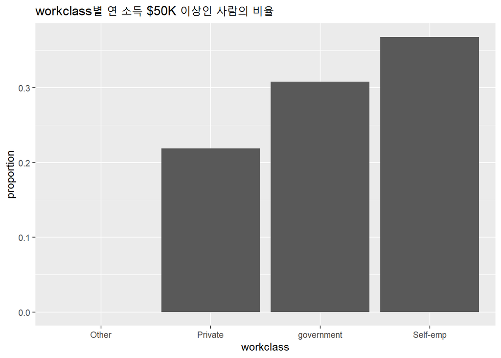

```r
ggplot(data = new_df) +
  geom_bar(mapping = aes(x = fct_reorder(workclass, prop), y = prop), stat = "identity") +
  xlab("workclass") +
  ylab("proportion") +
  labs(title = "workclass별 연 소득 $50K 이상인 사람의 비율")
```

Other -> Private -> Government -> Self-emp 순으로 비율이 높아졌다. 특히 Other은 해당하는 관측값이 0개였다.

## Q13

```r
accuracy <- function(table) {
  return((table[1, 1] + table[2, 2])/(sum(table)))
}
```

```r
na <- colSums(is.na(adult_df))
na
```

```
##            age      workclass         fnlwgt      education  education_num
##              0           1836              0              0              0
## marital_status     occupation   relationship           race            sex
##              0           1843              0              0              0
##   capital_gain   capital_loss hours_per_week native_country         salary
##              0              0              0            583              0
```

```r
adult_df <- na.omit(adult_df)
```

우선 변수가 매우 많으므로 변수를 한 개씩 넣었을 때 aic가 작은 변수들을 몇 개 추려보자.

```r
set.seed(1234)

temp <- adult_df %>%
  initial_split(prop = 0.8)

train <- temp %>%
    training()

test <- temp %>%
  testing()


aic_vec <- c()
for(i in colnames(adult_df)[-15]) {
  formula <- str_c("salary ~ ", i)
  fit <- glm(formula, family = binomial, data = train)
  aic_vec <- c(aic_vec, fit$aic)
}
```

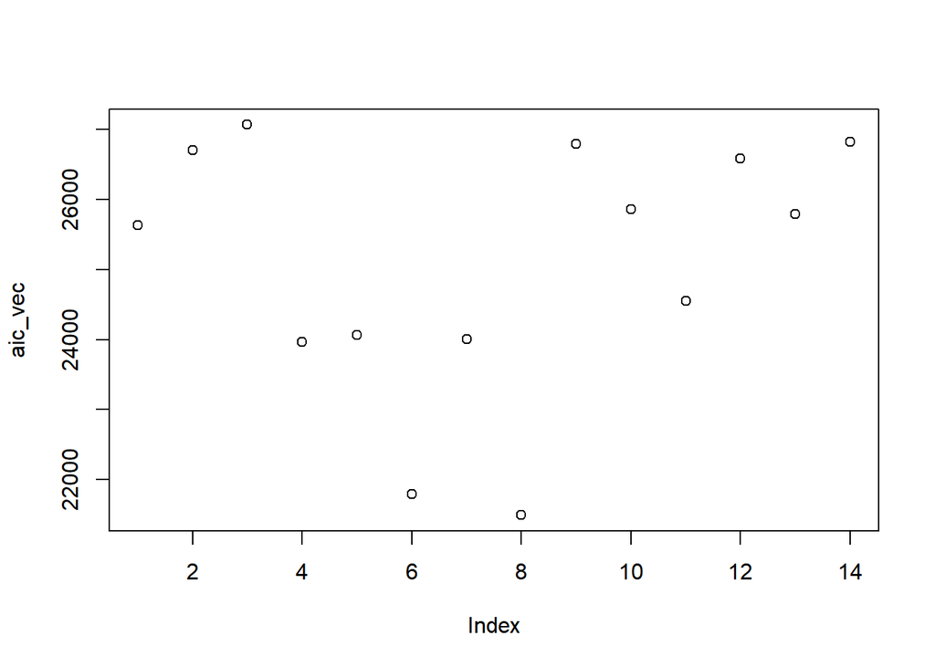

```r
plot(aic_vec)
```

education, education_num, marital_status, occupation, relationship, capital_gain 이렇게 6개의 변수의 aic가 작음을 확인할 수 있다. 이들을 기본으로 넣고 나머지를 aic가 작은 순서대로 추가하는 방식을 생각해보자.

```r
adult_df %>%
  group_by(native_country) %>%
  summarise(count = n())
```

```
## # A tibble: 41 × 2
##    native_country     count
##    <fct>              <int>
##  1 Cambodia              18
##  2 Canada               107
##  3 China                 68
##  4 Columbia              56
##  5 Cuba                  92
##  6 Dominican-Republic    67
##  7 Ecuador               27
##  8 El-Salvador          100
##  9 England               86
## 10 France                27
## # ℹ 31 more rows
```

한편, native_country는 level의 개수가 너무 많고 그 개수도 불균등하기 때문에 모델에서 제외시켰다.

```r
max_ind <- c()

formula <- c("salary ~ education + education_num + marital_status + occupation + relationship + capital_gain",
             "salary ~ age + education + education_num + marital_status + occupation + relationship + capital_gain",
             "salary ~ age + education + education_num + marital_status + occupation + relationship + sex + capital_gain",
             "salary ~ age + education + education_num + marital_status + occupation + relationship + sex + capital_gain + hours_per_week",
             "salary ~ age + workclass + education + education_num + marital_status + occupation + relationship + sex + capital_gain + hours_per_week",
             "salary ~ age + workclass + education + education_num + marital_status + occupation + relationship + race + sex + capital_gain + hours_per_week",
             "salary ~ age + workclass + fnlwgt + education + education_num + marital_status + occupation + relationship + race + sex + capital_gain + hours_per_week")

fit_vec <- c()
for(j in 1:7) {
    fit <- list(glm(formula[j], family = binomial, data = train))
    fit_vec <- c(fit_vec, fit)
}

for(j in 1:6) {
  print(anova(fit_vec[[j]], fit_vec[[j+1]]))
}
```

```
## Analysis of Deviance Table
##
## Model 1: salary ~ education + education_num + marital_status + occupation +
##     relationship + capital_gain
## Model 2: salary ~ age + education + education_num + marital_status + occupation +
##     relationship + capital_gain
##   Resid. Df Resid. Dev Df Deviance
## 1     24088      16484
## 2     24087      16333  1      151
## Analysis of Deviance Table
##
## Model 1: salary ~ age + education + education_num + marital_status + occupation +
##     relationship + capital_gain
## Model 2: salary ~ age + education + education_num + marital_status + occupation +
##     relationship + sex + capital_gain
##   Resid. Df Resid. Dev Df Deviance
## 1     24087      16333
## 2     24086      16226  1   106.79
## Analysis of Deviance Table
##
## Model 1: salary ~ age + education + education_num + marital_status + occupation +
##     relationship + sex + capital_gain
## Model 2: salary ~ age + education + education_num + marital_status + occupation +
##     relationship + sex + capital_gain + hours_per_week
##   Resid. Df Resid. Dev Df Deviance
## 1     24086      16226
## 2     24085      15966  1   260.69
## Analysis of Deviance Table
##
## Model 1: salary ~ age + education + education_num + marital_status + occupation +
##     relationship + sex + capital_gain + hours_per_week
## Model 2: salary ~ age + workclass + education + education_num + marital_status +
##     occupation + relationship + sex + capital_gain + hours_per_week
##   Resid. Df Resid. Dev Df Deviance
## 1     24085      15966
## 2     24082      15943  3   22.635
## Analysis of Deviance Table
##
## Model 1: salary ~ age + workclass + education + education_num + marital_status +
##     occupation + relationship + sex + capital_gain + hours_per_week
## Model 2: salary ~ age + workclass + education + education_num + marital_status +
##     occupation + relationship + race + sex + capital_gain + hours_per_week
##   Resid. Df Resid. Dev Df Deviance
## 1     24082      15943
## 2     24078      15933  4   10.047
## Analysis of Deviance Table
##
## Model 1: salary ~ age + workclass + education + education_num + marital_status +
##     occupation + relationship + race + sex + capital_gain + hours_per_week
## Model 2: salary ~ age + workclass + fnlwgt + education + education_num +
##     marital_status + occupation + relationship + race + sex +
##     capital_gain + hours_per_week
##   Resid. Df Resid. Dev Df Deviance
## 1     24078      15933
## 2     24077      15922  1   10.425
```

deviance를 비교했을 때 모든 모델이 H0를 기각하여 각 변수가 유의하다고 볼 수 있으나, practical한 관점에서 deviance가 적은 마지막 두 모델은 제외하기로 결정했다.

```r
for(i in 1:100) {
  temp <- adult_df %>%
    initial_split(prop = 0.8)

  train <- temp %>%
    training()

  test <- temp %>%
    testing()

  acc <- c()

  for(j in 1:5) {
    fit <- glm(formula[j], family = binomial, data = train)
    pred_val <- predict.glm(fit, newdata = test)
    val <- ifelse(exp(pred_val)/(1 + exp(pred_val)) > 0.5, ">50K", "<=50K")
    tb1 <- table(real = test$salary, pred = val)
    acc <- c(acc, accuracy(tb1))
  }

  max_ind <- c(max_ind, which.max(acc))
}
```

```r
tb <- table(max_ind)
mode_value <- as.numeric(names(tb)[which.max(tb)])
mode_value
```

```
## [1] 5
```

```r
fit <- glm(formula[mode_value], family = binomial, data = adult_df)
pred_val <- predict.glm(fit, newdata = test)
val <- ifelse(exp(pred_val)/(1 + exp(pred_val)) > 0.5, ">50K", "<=50K")
tb1 <- table(real = test$salary, pred = val)
acc <- accuracy(tb1)
print(acc)
```

```
## [1] 0.8476711
```

정확도는 0.848이 나온다.

```r
adult_test <- read_csv("adult.test", col_names = FALSE, na = c("?", "NA"), skip = 1)
```

```r
colnames(adult_test) <- column_names
colnames(adult_test)[15] <- "salary"
adult_test <- adult_test %>%
  map_df(convert_chr_to_fac, .x = .)

adult_test <- adult_test %>%
  mutate(workclass = fct_collapse(workclass, "government" = str_subset(levels(adult_test$workclass), "-gov$"),
                                  "Self-emp" = str_subset(levels(adult_test$workclass), "^Self-emp"))) %>%
  mutate(workclass = fct_lump_min(workclass, 20, other_level = "Other"))

adult_test <- na.omit(adult_test)

pred_val <- predict.glm(fit, newdata = adult_test)
val <- ifelse(exp(pred_val)/(1 + exp(pred_val)) > 0.5, ">50K", "<=50K")
tb1 <- table(real = adult_test$salary, pred = val)
acc <- accuracy(tb1)
print(acc)
```

```
## [1] 0.8440903
```

정확도는 0.844 정도이다.